# Two-Sample Tests: Lecture Notes

## 4.5 Permutation Test on Birth-weight Data

```r
set.seed(42)
x_b <- birth$weight[birth$habit == "nonsmoker"]
y_b <- birth$weight[birth$habit == "smoker"]

combined_b <- c(x_b, y_b)
m_b        <- length(x_b)
N_b        <- length(combined_b)
T_obs_b    <- mean(x_b) - mean(y_b)

T_perm_b <- replicate(1e6, {
  perm <- sample(combined_b)
  mean(perm[1:m_b]) - mean(perm[(m_b+1):N_b])
})

# One-sided p-value: P(T >= T_obs)
p_perm_b <- mean(T_perm_b >= T_obs_b)
```

```r
# Compare to the parametric t-test
t_pval <- t.test(x_b, y_b, alternative = "greater")$p.value

cat("Permutation p-value:", p_perm_b, "\n")
```

```
Permutation p-value: 9e-06
```

```r
cat("t-test p-value:     ", t_pval,   "\n")
```

```
t-test p-value:      0.0003032835
```

```r
# Both are very small and agree with each other
```

**TipWhen are permutation tests especially useful?**

- Small samples where $N(\mu, \sigma^2)$ is doubtful
- Non-standard test statistics (a ratio, a range, a correlation) — the permutation framework works for **any** statistic
- When you want an exact (or very accurate Monte Carlo) $p$-value without distributional assumptions

# 5 Wilcoxon Rank-Sum / Mann-Whitney Test

## 5.1 Motivation

The **Wilcoxon rank-sum test** is a nonparametric alternative to the two-sample $t$-test that works for any continuous distribution.

**Setup:**

- $X_1, \ldots, X_m \overset{iid}{\sim} F(x)$ and $Y_1, \ldots, Y_n \overset{iid}{\sim} G(y)$
- Location shift model: $G(y) = F(y - \Delta)$
- $H_0: \Delta = 0$ vs $H_1: \Delta \ne 0$ (or one-sided)

**Procedure:**

1. Combine all $N = m + n$ observations and rank from $1$ to $N$
2. Compute $W_X = \sum_{i=1}^m R_i$ (sum of ranks for the $X$ group)

## 5.2 Mann-Whitney $U$ Statistic

The **Mann-Whitney $U$** counts the number of pairs $(X_i, Y_j)$ where $X_i > Y_j$, called $U_X$. Similarly, if you count the number of pairs where $Y_i > x_j$, it is $U_Y$. We often think of the comparisons as “pairwise tournaments”.

When we assume the samples are independent and continuous, the probability of a tie is zero, and hence, each of the $mn$ pairs of $(X_i, Y_j)$ for $1 \le i \le m, 1 \le j \le n$, should either have the $X$ value winning or the $Y$ value winning. Hence, it should follow that $U_X + U_Y = mn$, trivially.

Under the null hypothesis, the two samples should be well mixed and the the average should be near half the number of pairs, i.e., $mn/2$ and deviations should make $U$ statistics either very large or very small (compared to the midpoint).

It is also true that the $U$ test and the Wilcoxon rank sum test are equivalent, and they are often clubbed together and called Wilcoxon-Mann-Whitney test. The rank sum test was proposed by a chemist Frank Wilcoxon in 1945 and the $U$ test was proposed in 1947 by Henry Mann and Donald Whitney.

It is easy to prove why they are equivaent: one way of seeing the equivalence is that they differ by a constant (independent of the sampling variability!)

$$U_X = W_X - \frac{m(m+1)}{2}, \qquad U_Y = mn - U_X$$

This is also the reason why R’s `wilcox.test()` returns $U_X$ (but is labeled `W` in output).

## 5.3 Pouring Times Example

```r
x <- c(12.6, 11.2, 11.4, 9.4, 13.2, 12.0)   # before lunch
y <- c(16.4, 15.4, 14.1, 14.0, 13.4, 11.3)  # after lunch
```

$$H_0: \Delta = 0 \quad \text{vs} \quad H_1: \Delta < 0$$

```r
wilcox.test(x, y, paired = FALSE, alternative = "less")
```

```
    Wilcoxon rank sum exact test

data:  x and y
W = 4, p-value = 0.01299
alternative hypothesis: true location shift is less than 0
```

[output not shown]

The $p$-value $0.013 < 0.05$. We reject $H_0$.

### 5.3.1 Extracting values from the test object

```r
twotest <- wilcox.test(y, x, paired = FALSE, alternative = "greater")
names(twotest)
```

```
[1] "statistic"   "parameter"   "p.value"     "null.value"  "alternative"
[6] "method"      "data.name"
```

```r
## [1] "statistic"   "parameter"   "p.value"     "null.value"
## [5] "alternative" "method"      "data.name"

twotest$statistic
```

```
 W
32
```

```r
##  W
## 32

twotest$p.value
```

```
[1] 0.01298701
```

```r
## [1] 0.01298701
```

## 5.4 Mind the Alternative

The order in which you supply the `x` and `y` argument matters (not just here, but in all other instances, re-read the `logics in R` tutorial again!). In this case, the difference is critical for one-sided testing. If you switch `x` and `y`, remember to switch the alternative too.

```r
# x first, y second → alternative = "less"
wilcox.test(x, y, paired = FALSE, alternative = "less")
```

```
    Wilcoxon rank sum exact test

data:  x and y
W = 4, p-value = 0.01299
alternative hypothesis: true location shift is less than 0
```

```r
# W = 4, p-value = 0.01299

# y first, x second → alternative = "greater"
wilcox.test(y, x, paired = FALSE, alternative = "greater")
```

```
    Wilcoxon rank sum exact test

data:  y and x
W = 32, p-value = 0.01299
alternative hypothesis: true location shift is greater than 0
```

```r
# W = 32, p-value = 0.01299
```

Note: $4 + 32 = 36 = 6 \times 6 = mn$ ✓ — the two $U$ statistics always sum to $mn$.

## 5.5 Formula Interface

```r
xydata <- rbind(
  data.frame(values = x, grp = "x"),
  data.frame(values = y, grp = "y")
)

wilcox.test(values ~ grp, data = xydata, alternative = "less")
```

```
    Wilcoxon rank sum exact test

data:  values by grp
W = 4, p-value = 0.01299
alternative hypothesis: true location shift is less than 0
```

```r
##   Wilcoxon rank sum exact test
## W = 4, p-value = 0.01299
## alternative hypothesis: true location shift is less than 0
```

## 5.6 CLT Approximation

For large $m, n$, the $U$ statistic is approximately $N(\mu_U, \sigma_U^2)$:

$$Z = \frac{U - \mu_U}{\sigma_U}, \qquad \mu_U = \frac{mn}{2}, \qquad \sigma_U^2 = \frac{mn(m+n+1)}{12}$$

Apply a **continuity correction** of $\pm 0.5$.

**Case 1: `y` first, `"greater"`** — subtract $0.5$, use $P(Z \ge z)$:

```r
U_Y    <- wilcox.test(y, x, paired = FALSE, alternative = "greater")$statistic
m      <- length(y);  n <- length(x)
clt.mu <- m * n / 2
clt.s2 <- m * n * (m + n + 1) / 12

(Z_score <- (U_Y - clt.mu - 0.5) / sqrt(clt.s2))
```

```
      W
2.16173
```

```r
(P.value <- 1 - pnorm(Z_score))
```

```
         W
0.01531949
```

**Case 2: `x` first, `"less"`** — add $0.5$, use $P(Z \le z)$:

```r
U_X    <- wilcox.test(x, y, paired = FALSE, alternative = "less")$statistic
m      <- length(x);  n <- length(y)

(Z_score <- (U_X - clt.mu + 0.5) / sqrt(clt.s2))
```

```
       W
-2.16173
```

```r
(P.value <- pnorm(Z_score))
```

```
         W
0.01531949
```

## 5.7 Class Exam Data

> “An instructor decided to run two slight variations of the same exam. Prior to passing out the exams, they shuffled the exams together to ensure each student received a random version. Anticipating complaints from students who took Version B, they would like to evaluate whether the difference observed in the groups is so large that it provides convincing evidence that Version B was more difficult (on average) than Version A.”

```r
classdata    <- read.csv("https://www.openintro.org/data/csv/classdata.csv")
classdata_ab <- classdata[classdata$lecture %in% c("a", "b"), ]
```

### 5.7.1 Visualize and summarize

```r
library(dplyr)
classdata_ab %>%
  group_by(lecture) %>%
  summarize(mean = mean(m1), median = median(m1), sd = sd(m1), n = n())
```

```
# A tibble: 2 × 5
  lecture  mean median    sd     n
  <chr>   <dbl>  <dbl> <dbl> <int>
1 a        75.1   73.5  13.9    58
2 b        72.0   72    13.8    55
```

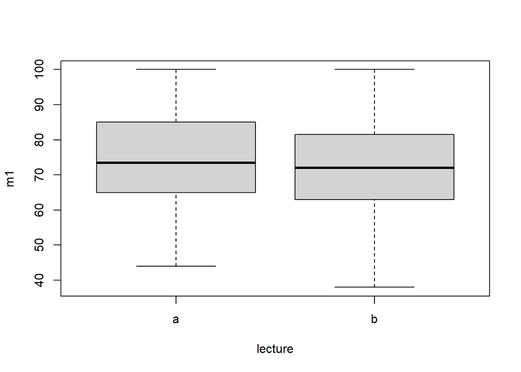

```r
boxplot(m1 ~ lecture, data = classdata_ab)
```

### 5.7.2 Test the difference

$$H_0: \mu_a = \mu_b \qquad H_1: \mu_a > \mu_b$$

```r
## Your code here!
wilcox.test(m1 ~ lecture, data = classdata_ab, alternative = "greater")
```

```
    Wilcoxon rank sum test with continuity correction

data:  m1 by lecture
W = 1777.5, p-value = 0.1478
alternative hypothesis: true location shift is greater than 0
```

```r
t.test(m1 ~ lecture, data = classdata_ab, alternative = "greater")
```

```
    Welch Two Sample t-test

data:  m1 by lecture
t = 1.2073, df = 110.76, p-value = 0.115
alternative hypothesis: true difference in means between group a and group b is greater than 0
95 percent confidence interval:
 -1.174153       Inf
sample estimates:
mean in group a mean in group b
       75.10345        71.96364
```

Do both tests agree? Which would you trust more, and why?